# Predicting District School Funding and Educational Outcomes

Team Po-Data Science: Amy Luo, Austin Tucker, Han Choi, Juliet McCann, Yeeun Lee

December 2021

## Part 1: Predicting District Academic Achievement

In the first part of our project, we aim to understand the variables that predict academic achievement on a district level. This section of our project has three components. First, we will use explortory data analysis and machine learning modeling to determine key predictors of academic achievment on which to focus. Next we will take a closer look at some socio-economic status, unemployment, and poverty as predictors of academic achievement, using Washington and Massachusetts as case studies. Finally, we will explore how receiving free lunch at school predicts academic success.

### Data Source:

```r
# Load achievement data (district, CS, pooled)
# data obtained from: "https://stacks.stanford.edu/file/druid:db586ns4974/seda_geodist_pool_cs_4.0.dta"
# This data set contains data on the outcome of interest, district academic achievement.
# In this data set, academic achievement is measured in terms of standard deviation
# units and is what we will be using for our regression analyses
ach <- read_dta("seda_geodist_pool_cs_4.0.dta")

# Load main covariates data (district level), pool
# data obtained from https://stacks.stanford.edu/file/druid:db586ns4974/district%20covariates.dta"
# This data set contains an extensive list of covariates that will be tested as
# predictors of our outcome, academic achievement
covs <- read_dta("seda_cov_geodist_pool_4.0.dta")


# Merge files together. This keeps only matched districts.
dat <- inner_join(ach, covs, by = c("sedalea", "fips"))


# Subset to the "all" subgroup estimates for all students, only districts
# with an estimate of average achievement, unemployment, poverty, ses avergage, and non-missing SES.
dat <- filter(dat,
              subgroup == "all",
              !is.na(cs_mn_avg_ol),
              !is.na(unempavgall),
              !is.na(povertyavgall),
              !is.na(sesavgall))
nrow(dat)
```

```
## [1] 12438
```

After creating this data set, we noticed that the covariate data set that we used did not include variables related to district spending. This is an area of interest of our team, as it shows how policies and funding can play a round in academic outcomes. Therefore, obtained an additional SEDA dataset with district spending included and merged this with the data set above.

```r
#importing the data set that includes variables of interest: ppexp_tot, ppexp_inst, pprev_tot
spending <- read_dta("district covariates.dta")

# Subsetting data set to only include variables of interest
# also including the district ID, titled leaid here, and state ID (fips) for joining
spending <- subset(spending, select = c(ppexp_tot, ppexp_inst, pprev_tot, leaid, fips))

# since the name of the district ID variable in the dataset "spending" (leaid) is different
# from the district ID variable in the data set "dat" (sedalea), we need to change this

spending <- rename(spending, sedalea = leaid)

#checking the class of `sedalea` in "spending" df
class(spending$sedalea)
```

```
## [1] "character"
```

```r
#checking the class of `sedalea` in "dat" df

class(dat$sedalea)
```

```
## [1] "numeric"
```

```r
#converting `sedalea` in "spending" df to numeric class so that they are both of the same class
spending$sedalea <- as.numeric(spending$sedalea)

#confirming that `sedalea` in "spending" is now numeric
class(spending$sedalea)
```

```
## [1] "numeric"
```

```r
# Merge files together. This keeps only matched districts.
dat <- inner_join(dat, spending, by = c("sedalea", "fips"))
```

### Part 1a: Deciding the predictors of interest

### Explorotory Analysis

For the exploratory data analysis, we start by summarizing our outcome of interest: district academic achievement. As mentioned in the code above, the data set that we imported for our measures academic achievement in terms of standard deviation units away form the national mean. While we can compare relative performance using this measure, interpreting standard deviation units for exploratory data analysis is not too useful, and can be difficult to interpret. Therefore, we will import another SEDA dataset that measures academic achievement outcomes in terms of “grade levels” using the variable `gcs_mn_avg_ol.`

```r
# loading SEDA data that includes academic achievement in "grade levels"

ach.EDA <- read_dta("seda_geodist_pool_gcs_4.0.dta")

ach.EDA <- filter(ach.EDA,
              subgroup == "all",
              !is.na(gcs_mn_avg_ol))
```

To begin our exploratory data analysis on our outcome, it would be helpful to first take a look at how much variation we have in our data. We can visualize this first by using a histogram.

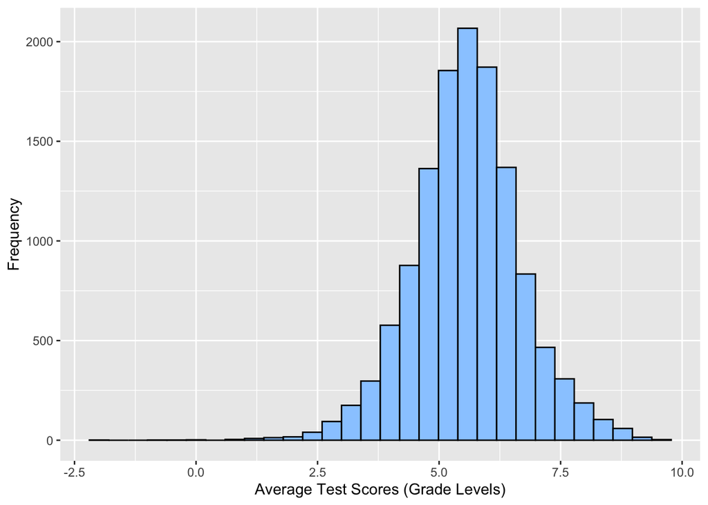

```r
ggplot(aes(x=gcs_mn_avg_ol), data = ach.EDA) +
  geom_histogram(color="black", fill="#99CCFF") +
  xlab("Average Test Scores (Grade Levels)") +
  ylab("Frequency")
```

Our team is hoping to understand some of the district-level factors that leads to such variation in academic performance in the United States.

Before moving onto our analysis, we can also look at the variation in test scores between and within states using box plots:

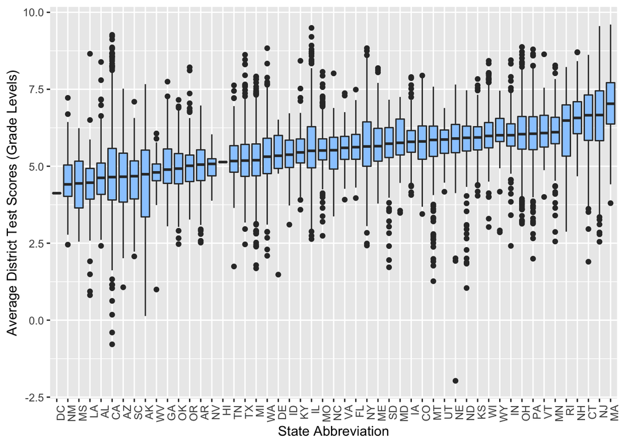

```r
ach.EDA %>% mutate(stateabb = reorder(stateabb, gcs_mn_avg_ol, FUN = median)) %>%
  ggplot(aes(stateabb, gcs_mn_avg_ol, group = stateabb)) +
  geom_boxplot(fill = "#99CCFF") +
  labs(x = "State Abbreviation", y = "Average District Test Scores (Grade Levels)") + theme(axis.text.x = element_text(angle = 90, hjust = 1))
```

In our analysis, we hope to understand the factors that contribute to such variation between districts across the United States. The covariate data set has many different variables, many of which may predict district test scores. However, for the purpose of our project, we want to focus in on a few key covariates in order to produce more focused and meaningful conclusions.

To decide our priority predictors, we can start of by visually summarizing the overall relationships between these variables and our outcome for academic achievement, `cs_mn_avg_ol`. In contrast our achievement variable used in the plots above, `cs_mn_avg_ol` measures academic achievement in terms of standard deviations away from the national average.

Before we begin, it would be helpful to summarize create a list of our predictors for this analysis. The covariates we are exploring include:

- `urban`: if the district is in a city/urban locale (binary; 0 = no, 1 = yes)
- `avgrdall`: average per grade enrollment (number of students)
- `perfrl`: percent free lunch in the grade (percentage; range: 0-1)
- `perell`: % of all students in the district that are English Language Learners (ELL ) (percentage; range: 0-1)
- `perspeced`: % of all students in the district that qualify for Special Education (percentage; range: 0-1)
- `nsch`: number of schools in district (count)
- `aides`: number of instructional aides (count)
- `corsup`: number of instructional coordinators and supervisors (count)
- `elmgui`: number of Elementary Guidance Counselors (count)
- `stutch_all`: pupil teacher ratio (ratio of number of pupils to number of students in district)
- `ppexp_tot`: total per pupil expenditures (dollars)
- `ppexp_inst`: total per pupil expenditures on instruction (dollars)
- `pprev_tot` : revenue per pupil (dollars)
- `baplus_all`: % of adults in district with at least a bachelors degree (percentage)
- `poverty517_all`: % of households with 5-17 year olds in poverty (percentage)
- `singmom_all` % of household with children with single mom (percentage)
- `snap_all` : % of households receiving snap benefits (percentage)
- `samehouse_all`: % of households living in the same house as last year (percentage)
- `unemp_all` : % unemployed in the district (percentage)
- `inf_fem`: percent of 25 - 64 year old females in labor force (percentage)
- `teenbirth_all`: percent of 15-19 year olds giving birth in district (percentage)
- `sesall`: standardized socio-economic status composite score computed as the first principal component factor score of the following measures: median income, percent with a bachelor’s degree or higher, poverty rate, SNAP rate, single mother headed household rate, and unemployment rate
- `cs_mn_avg_ol`: District test-based achievement math and reading scores from ordinary least quares estimate

For the continuous predictors, we can do scatter plots:

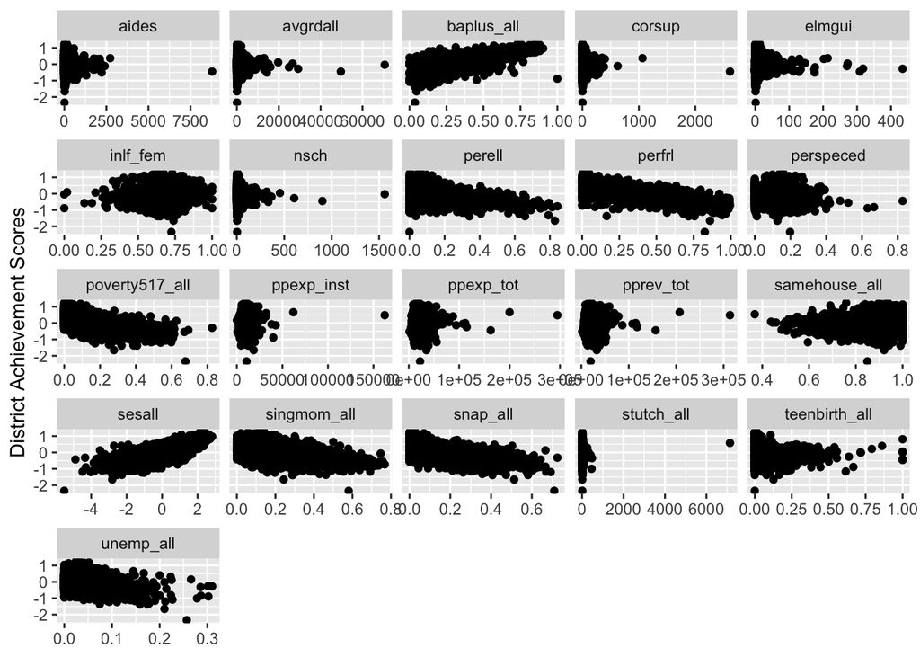

```r
ML.dta <- read.csv("complete_data_ML.csv")

ML.dta %>%
  gather(predictor, value, c(avgrdall, perfrl, perell, perspeced, nsch, aides,
                             corsup, elmgui, stutch_all, ppexp_tot, ppexp_inst,
                             pprev_tot, baplus_all, poverty517_all, singmom_all,
                             snap_all, samehouse_all, unemp_all, inlf_fem,
                             teenbirth_all, sesall)) %>%
  ggplot(aes(x = value, y = cs_mn_avg_ol)) +
  geom_point() +
  facet_wrap(~ predictor, scales = 'free_x') +
  xlab(NULL) + ylab("District Achievement Scores")
```

Our above scatter plots confirm what we initially suspected: many of these variables do in fact predict academic achievement. For example, it appears `baplus_all`, the percent of adults in the district with a bachelor’s degree, is positively correlated with academic achievement. On the other hand, the percent of households in poverty or with a single mother appear to be negatively correlated. For other variables, such as per pupil expenditure (`ppexpt_inst`), the association is less clear. Overall, while these scatterplots give us a general sense of what variables may be important, it still is not clear which variables matter the most for academic achievement.

To answer this question, we will turn to machine learning models. We will first use random forest to determine variables of importance in predicting academic achievement, as measured by the Gini coeffient. We will then addition use a regression tree to see which variables are included to predict relative test scores.

## Using Machine Learning to Determine Predictors of Importance

### Creating the Training and Test Sets

```r
#creating a data partition that splits my data frame in half
index_train<- createDataPartition(y = ML.dta$low_dist_ach, times =1, p=0.05, list = FALSE)

#labeling the first "slice" as the train set
train_set <- slice(ML.dta, index_train)

#labelign the second "slice" as the test set
test_set <- slice(ML.dta, -index_train)
```

### Random Forest

Next, we will use a Random Forest Model to determine variables of importance, as measured using the Gini Coefficient.

```r
set.seed(1)

#fitting a random forest with all 22 predictors
rf_fit <- randomForest(cs_mn_avg_ol ~ urban + avgrdall + perfrl + perell + perspeced + nsch + aides + corsup + elmgui + stutch_all + ppexp_tot + ppexp_inst + pprev_tot + baplus_all + poverty517_all + singmom_all + snap_all + samehouse_all + unemp_all + inlf_fem + teenbirth_all + sesall, data = train_set, mtry = 22, importance = TRUE)


variable_importance <- importance(rf_fit)

variable_importance_death <- tibble(Predictor = rownames(variable_importance),
                  Gini = variable_importance[,1]) %>%
                  arrange(desc(Gini))

kable(variable_importance_death[1:22,])
```

| Predictor | Gini |
| --- | --- |
| perfrl | 86.9353911 |
| baplus_all | 24.0024029 |
| sesall | 20.0461643 |
| perell | 12.9315121 |
| ppexp_tot | 11.5824923 |
| teenbirth_all | 11.3873691 |
| unemp_all | 8.4384998 |
| stutch_all | 8.4351420 |
| pprev_tot | 7.9138196 |
| poverty517_all | 7.7502375 |
| singmom_all | 7.6720859 |
| ppexp_inst | 7.4589011 |
| avgrdall | 7.1971834 |
| snap_all | 5.9086864 |
| corsup | 5.6447025 |
| aides | 5.3563731 |
| nsch | 4.8023925 |
| elmgui | 4.1630042 |
| samehouse_all | 3.7716331 |
| inlf_fem | 1.1231543 |
| perspeced | -0.8670106 |
| urban | -1.1466391 |

```r
#predicting probability of estimates for test set
probs_rf <- predict(rf_fit, newdata = test_set, type = "class")

#converting probabilities to predicted response labels

y_hat_rf <- ifelse(probs_rf > 0.5, 1, 0)

#obtaining the confusion matrix

confusionMatrix(data = as.factor(y_hat_rf),
                reference = as.factor(test_set$low_dist_ach),
               positive = "1")
```

```
## Confusion Matrix and Statistics
##
##           Reference
## Prediction    0    1
##          0 9396 1703
##          1  650    0
##
##                Accuracy : 0.7997
##                  95% CI : (0.7924, 0.8069)
##     No Information Rate : 0.8551
##     P-Value [Acc > NIR] : 1
##
##                   Kappa : -0.0871
##
##  Mcnemar's Test P-Value : <2e-16
##
##             Sensitivity : 0.00000
##             Specificity : 0.93530
##          Pos Pred Value : 0.00000
##          Neg Pred Value : 0.84656
##              Prevalence : 0.14495
##          Detection Rate : 0.00000
##    Detection Prevalence : 0.05532
##       Balanced Accuracy : 0.46765
##
##        'Positive' Class : 1
##
```

### Regression Tree

To supplement the above results from the random forest, we can also fit our data to a regression tree model.

```r
tree = tree(cs_mn_avg_ol ~ urban + avgrdall + perfrl + perell + perspeced +
              nsch + aides + corsup + elmgui + stutch_all + ppexp_tot +
              ppexp_inst + pprev_tot + baplus_all + poverty517_all +
              singmom_all + snap_all + samehouse_all + unemp_all +
              inlf_fem + teenbirth_all + sesall, data = train_set)

summary(tree)
```

```
##
## Regression tree:
## tree(formula = cs_mn_avg_ol ~ urban + avgrdall + perfrl + perell +
##     perspeced + nsch + aides + corsup + elmgui + stutch_all +
##     ppexp_tot + ppexp_inst + pprev_tot + baplus_all + poverty517_all +
##     singmom_all + snap_all + samehouse_all + unemp_all + inlf_fem +
##     teenbirth_all + sesall, data = train_set)
## Variables actually used in tree construction:
## [1] "perfrl"     "sesall"     "baplus_all" "unemp_all"
## Number of terminal nodes:  8
## Residual mean deviance:  0.03186 = 19.46 / 611
## Distribution of residuals:
##      Min.   1st Qu.    Median      Mean   3rd Qu.      Max.
## -0.829400 -0.109800  0.008713  0.000000  0.111900  0.577900
```

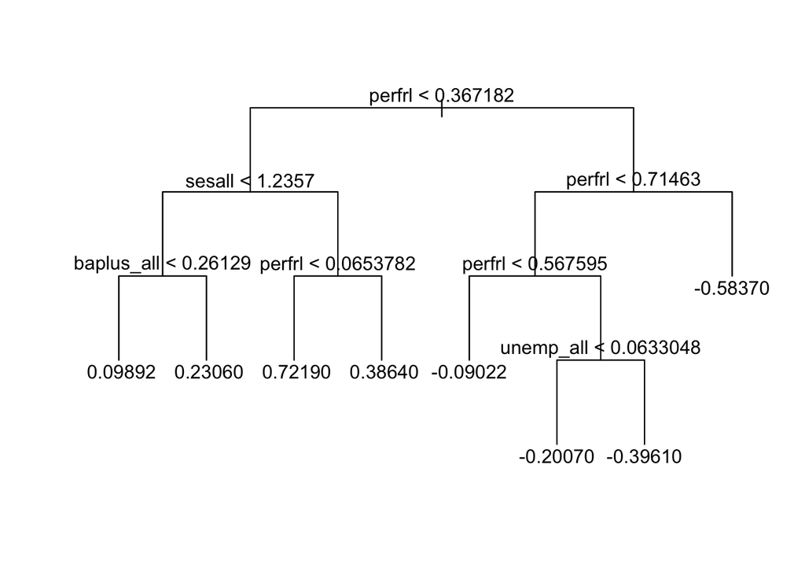

```r
plot(tree, type = "uniform")
text(tree, cex = 1)
```